# MA 575 HW 9

Benjamin Draves

November 21

### Exercise 9.1

#### (a)

First, to find the eigenvalues of $X^{T}X$ we solve
$$\begin{align*}
X^{T}Xv &= \gamma v\\
(X^{T}X - \gamma I)v &= 0
\end{align*}$$
Here $\gamma$ is the eigenvalue and $v$ is the eigenvector corresponding to $X^{T}X$. Now, let $Y^{T}Y = X^TX + \lambda I$. Then we can find the eigenvalues of $Y^{T}T$ by solving the equation
$$\begin{align*}
Y^{T}Yu &= \theta u\\
(Y^{T}Y - \theta I)u &= 0
\end{align*}$$
Here $\theta$ is the eigenvalue and $u$ is the eigenvector corresponding to $Y^{T}Y$. But notice, by the way we defined $Y^TY$ we can reduce this further by
$$\begin{align*}
(Y^{T}Y - \theta I)u &= 0\\
(X^TX + \lambda I - \theta I)u &= 0\\
(X^TX -(\theta-\lambda)I)u &= 0\\
\end{align*}$$

Notice that this was just the system we were trying to solve above. That is the eigenvalues and eigenvectors $(\gamma_i,v_i)$ corresponding to $X^{T}X$ are in direct correspondence to the $(\theta_i - \lambda, u_i)$ pairs. But since $\lambda$ is constant in all of these equations, we have $\lambda_{i}(X^{T}X) = \lambda_{i}(Y^{T}Y) - \lambda$. This gives
$$\lambda_i(X^TX + \lambda I) = \lambda_{i}(X^{T}X) + \lambda$$
Therefore, we can write the condition number as
$$\kappa(X^TX + \lambda I) = \frac{\lambda_m(X^TX + \lambda I)}{\lambda_1(X^TX + \lambda I} = \frac{\lambda_m(X^TX) + \lambda}{\lambda_1(X^TX) + \lambda}$$

#### (b)

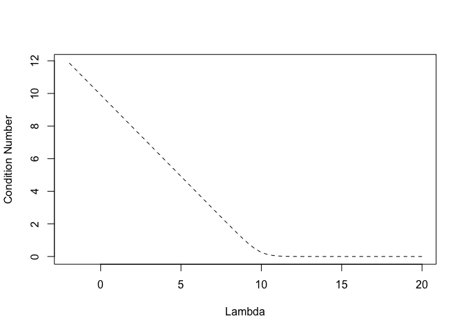

```r
#read in/format data
dat = read.csv("~/Desktop/Courses/MA 575/book_data/reducedbikedata2011.csv")

#form the p + 1 data matrix
X = as.matrix(dat[,-c(1,2)])

#make the design matrix
design = t(X) %*% X

#get eigen values from design
evals = eigen(design)$values
max = max(evals)
min = min(evals)

#define data structures
lambda <- 10^seq(20, -2, length = 100)
Y = length(lambda)

#get condition values
for(i in 1:length(lambda)){
  val = (max + lambda[i])/(min + lambda[i])
  Y[i] = log(val,10)
}

#make plot of condition numbers
plot(log(lambda, 10), Y, type = "l", xlab = "Lambda", ylab = "Condition Number", main = "", lty = 2)
```

From a numerical point of view, larger $\lambda$ will stabilize the inversion of $X^{T}X$ by adding larger and larger values to the main diagnose via the correction $\lambda I$. But notice as we let $\lambda \to \infty$, we require that all $\beta$ values are zero. This is because as we let any $\beta >0$, then the penalty will inflate the $RSS_{RIDGE}$ to infinity. Therefore, we face a trade off - numerical stability and penalization for problems with several predictors (i.e. $n<<p$) and the inferential task of relating the covariates to $Y$.Therefore, we should choose a $\lambda$ value that penalizes enough to ensure stability and provide structure to high dimensional problems while still allowing the model to fit the trends in the data.

### Exercise 9.2

We will fit all three models then comment below.

```r
#--------------------------
#
#       Data Prep
#
#--------------------------

#load in data
swiss <- datasets::swiss

#create model matrix/response vector
x = model.matrix(Fertility~., swiss)[,-1]
y = swiss$Fertility

#set up training/testing sets
set.seed(489)
train = sample(1:nrow(x), nrow(x)/2)
test = (1:nrow(x))[-train]

#--------------------------
#
#       OLS
#
#--------------------------

#OLS model/prediction
ols = lm(y~., data = swiss[,-1], subset = train)

#Prediction
pred_ols = as.numeric(predict(ols, newdata = swiss[test,-1]))

#Get MSE
mse_ols = mean((y[test] - pred_ols)^2)

#--------------------------
#
#       Ridge
#
#--------------------------

#fit Ridge
library("glmnet")
```

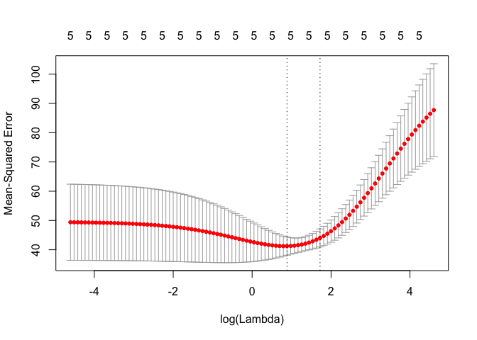

```r
lam = 10^seq(2, -2, length = 100)
ridge = glmnet(x[train,], y[train], lambda = lam, alpha = 0)

#CV to find lambda_opt
cv = cv.glmnet(x[train,], y[train], lambda = lam, nfolds = 5, alpha = 0)
plot(cv)
```

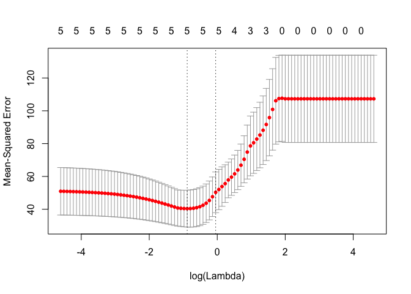

```r
lam_opt_ridge = cv$lambda.min

#find predictions
pred_ridge = predict(ridge, s= lam_opt_ridge, newx = x[test,])

#MSE calculations
mse_ols = mean((y[test] - pred_ols)^2)
mse_ridge = mean((y[test] - pred_ridge)^2)


#--------------------------
#
#       LASSO
#
#--------------------------
lasso = glmnet(x[train,], y[train], lambda = lam, alpha = 1)

#CV to find lambda_opt
cv = cv.glmnet(x[train,], y[train], lambda = lam, nfolds = 5, alpha = 1)
plot(cv)
```

```r
lam_opt_lasso = cv$lambda.min

#find predictions
pred_lasso = predict(lasso, s= lam_opt_lasso, newx = x[test,])

#get MSE
mse_lasso = mean((pred_lasso - y[test])^2)

#--------------------------
#
#       Compare Models
#
#--------------------------

#print all three MSE
message(paste("MSE OLS:", round(mse_ols,3),"\n MSE Lasso:", round(mse_lasso,3),"\n MSE Ridge:", round(mse_ridge,3)))
```

```
## MSE OLS: 106.009
##  MSE Lasso: 103.738
##  MSE Ridge: 93.136
```

```r
#get best coef
betas = data.frame(B.OLS = coef(ols))
betas$B.Ridge = predict(ridge, type = "coefficients", s = lam_opt_ridge)[1:6,]
betas$B.LASSO = predict(lasso, type = "coefficients", s = lam_opt_lasso)[1:6,]

#print all coefficents
print(betas)
```

```
##                        B.OLS     B.Ridge    B.LASSO
## (Intercept)      74.63669064 62.45392671 68.0347328
## Agriculture      -0.27810752 -0.12381476 -0.1931092
## Examination      -0.93921916 -0.48843634 -0.7672501
## Education        -0.35970838 -0.33455989 -0.2666706
## Catholic          0.06498258  0.06201879  0.0569043
## Infant.Mortality  1.37617843  1.23132670  1.3273270
```

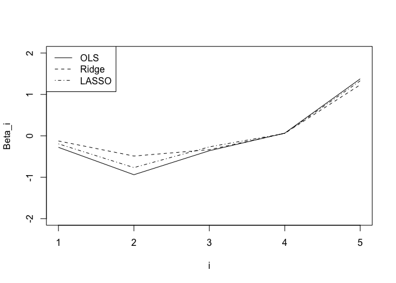

```r
#plot coefficents (except for intercept)
plot(1:5,betas[2:6,1], lty = 1, type = "l", ylim = c(-2,2), ylab = "Beta_i", xlab = "i")
points(1:5,betas[2:6,2],lty = 2,  type = "l")
points(1:5,betas[2:6,3], lty = 4, type = "l")
legend("topleft", legend = c("OLS", "Ridge", "LASSO"), lty = c(1,2,4))
```

Here we see that the MSE decreases as we increase our penalty. That is we have
$$MSE_{OLS}>MSE_{Lasso}>MSE_{Ridge}$$
Ridge performs very well, with sizable MSE reduction. I included a table of the final $\beta$ estimates from each model. Also included is a plot for the $\beta$ estimates except for the intercept. We notice as $\lambda$ increases, the $\beta$ terms tend to zero. This matches our intuition/interpretation as Lasso and Ridge as shrinkage estimators. For instance for $\beta_2$ we see great shrinkage, but for more important terms in the model (i.e. infant mortality) that the coefficients remain the same, even though it is statistically different than zero. This is a case where the penalization schemes improve on the OLS models significantly.